# Quiz1

Raymond Infante

2023-02-23

# Quiz 1: Kāne’ohe Bay, Hawai’i Chemistry Data

For this assignment, you will clone this repository, edit this README.md file with code and your responses in text following each question, and knit it to create an HTML file that you will push to your GitHub page. Your final submission will be an email to me with a link to your GitHub repository. No changes to this repository should be made after the end of class. Show all code and results needed to support your answer.

## 1) Is the data tidy? If not, explain how you could make the data tidy.

```r
df = read_csv("carbonate_chem_Kaneohe.csv")
```

In my opinion, looking the data. The data is “Tidy”.

1. Each Variables has its own columns
2. Each Observation are in a row
3. Each Value have its own “data cell”

This are characteristic of a Tidy Data, retrieved from [R for Data Science of Hadley Wickham and Garret Grolemund](https://r4ds.had.co.nz/)

## 2) Which survey date had the highest mean seawater temperature? Report mean ± standard deviation seawater temperature for each survey date to support your answer.

```r
df %>%
  select(date, temp) %>%
  group_by(date) %>%
  summarise(average = mean(temp), Standard_Deviation = sd(temp))
```

```
## # A tibble: 4 × 3
##   date      average Standard_Deviation
##   <chr>       <dbl>              <dbl>
## 1 12-Nov-16    26.6              0.345
## 2 26-Feb-17    23.2              0.441
## 3 29-Jun-16    27.6              0.990
## 4 31-Oct-15    27.6              0.273
```

According to the data. The date with the highest mean seawater temperature is **October 31, 2015** with a temperature mean of **27.63697 ± 0.2733986 °C**. Although is very comparable with the temperature of June 29, 2016 with a temperature mean of 27.61951 ± 0.9897524 °C.

## 3) Create a “publishable” plot of TA vs DIC for the “bleached” survey data.

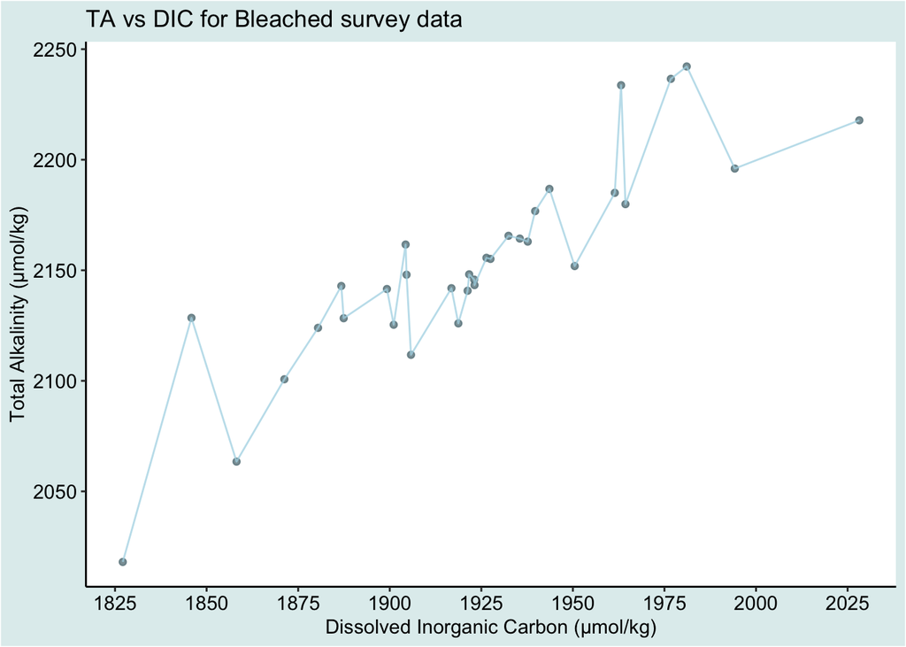

```r
df %>%
  filter(reefstatus== "Bleached") %>%
  select(reefstatus, ta, dic, date) %>%
  ggplot(aes(x = dic, y = ta))+
  geom_point(color = "lightblue4", alpha = 0.8)+
  geom_line(alpha = 0.75, color = "lightblue")+
  theme_classic()+
  labs(x = "Dissolved Inorganic Carbon (µmol/kg)", y = "Total Alkalinity (µmol/kg)", title = "TA vs DIC for Bleached survey data")+
  scale_x_continuous(breaks = seq(1800,2050,25)) + theme(axis.text = element_text(size = 11,
    colour = "black"), axis.text.x = element_text(size = 11),
    axis.text.y = element_text(size = 11),
    plot.background = element_rect(fill = "azure2"))
```

## Column names for the data in the attached file

Sample ID Number = “sample”  
Bleached or Recovery = “reefstatus”  
Date of sampling = “date”  
Time of samplng = “time”  
Latitude of sampling = “lat”  
Longitude of sampling = “long”  
Seawater temperature (°C) = “temp”  
Seawater salinity = “sal”  
Seawater total alkalinity (µmol/kg) = “ta”  
Seawater dissolved inorganic carbon (µmol/kg) = “dic”  
ISO time of sampling = “ISO_DateTime_Local”